# Data Exploration

```python
%matplotlib inline
import matplotlib.pyplot as plt
import seaborn as sns

import numpy as np
import pandas as pd
import os
```

```python
stats = pd.read_csv('stats.csv').drop('Unnamed: 0',axis=1)
schedule = pd.read_csv('sched.csv').drop(['Start (ET)','Unnamed: 2','Notes'],axis=1)
```

The countplot below shows the number of wins a home team has versus the number of wins that happen by the visiting team. False (the blue bar) indicates the count for home team wins and True (the green bar) shows the count for the number of times a visiting team has won. This graph uses the schedule for the 2015-2016 schedule until 3/6/2016.

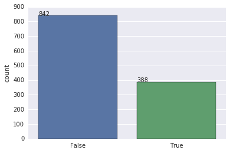

```python
ax = sns.countplot(x= (schedule['PTS'] > schedule['PTS.1']))
for p in ax.patches:
    height = p.get_height()
    ax.text(p.get_x(), height, '%1.0f'%(height))
```

The regression plot below shows that there is a small correlation between the number of wins a team has and how many fans show up to a home game. Although there is a correlation, there is no definite cause and effect connection between the two, since the number of wins does not differentiate between home wins and visitor wins the team has.

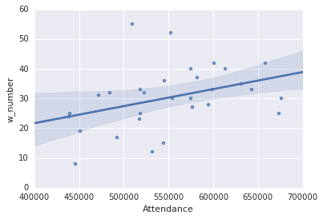

```python
sns.regplot(x='Attendance',y='w_number',data = stats);
```

The second regression plot here, below, shows a very positive correlation between the number of wins a team has and the effective field goal percentage, which adjusts for the fact that a 3-point field goal is worth one more point than a 2-point field goal. This shows it could be a valuable feature because of its strong correlation as well as its relatively small margin of error.

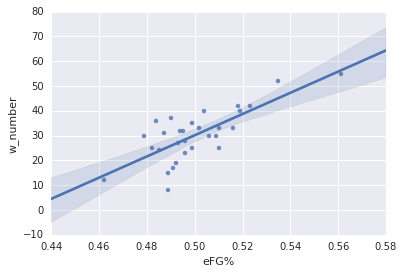

```python
sns.regplot(x='eFG%',y='w_number',data = stats);
```

The regression plot below, shows that there is a pretty strong relationship between a teams Offensive rating and the number of wins a team has throughout the season. The offensive rating is an estimate of points produced (by players) or scored (by teams) for every 100 possessions. I used this as a feature as part of my model becuase there is a pretty strong correlation with little error.

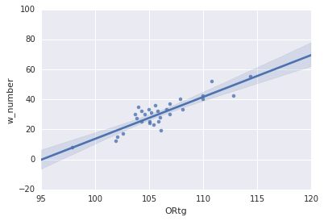

```python
sns.regplot(x ='ORtg',y='w_number',data=stats)
```

The two regression plots below show that there is a correlation between the shooting percentages (2 point percentage and 3points percentage) and number of wins a team has since making more baskets allows a team to score more.

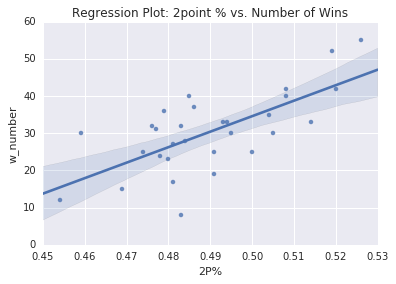

```python
sns.regplot(x='2P%',y='w_number',data=stats);
plt.title('Regression Plot: 2point % vs. Number of Wins');
```

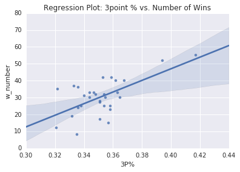

```python
sns.regplot(x='3P%',y='w_number',data=stats);
plt.title('Regression Plot: 3point % vs. Number of Wins');
```

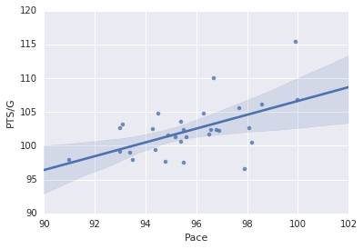

```python
sns.regplot(x='Pace',y='PTS/G',data=stats)
```

The plot below is a FacetGrid of distribution plots based on teams. The distrubtion plots represent the points spread distribution of final scores of each team in the NBA. The plots with a bellshaped curve shows that the teams record is pretty nuetral with the same amout of losses and wins. While other teams with a very narrow distribution plot show that they either have more wins than losses or vice versa.

```python
schedule['dif'] = schedule['PTS']-schedule['PTS.1']
```

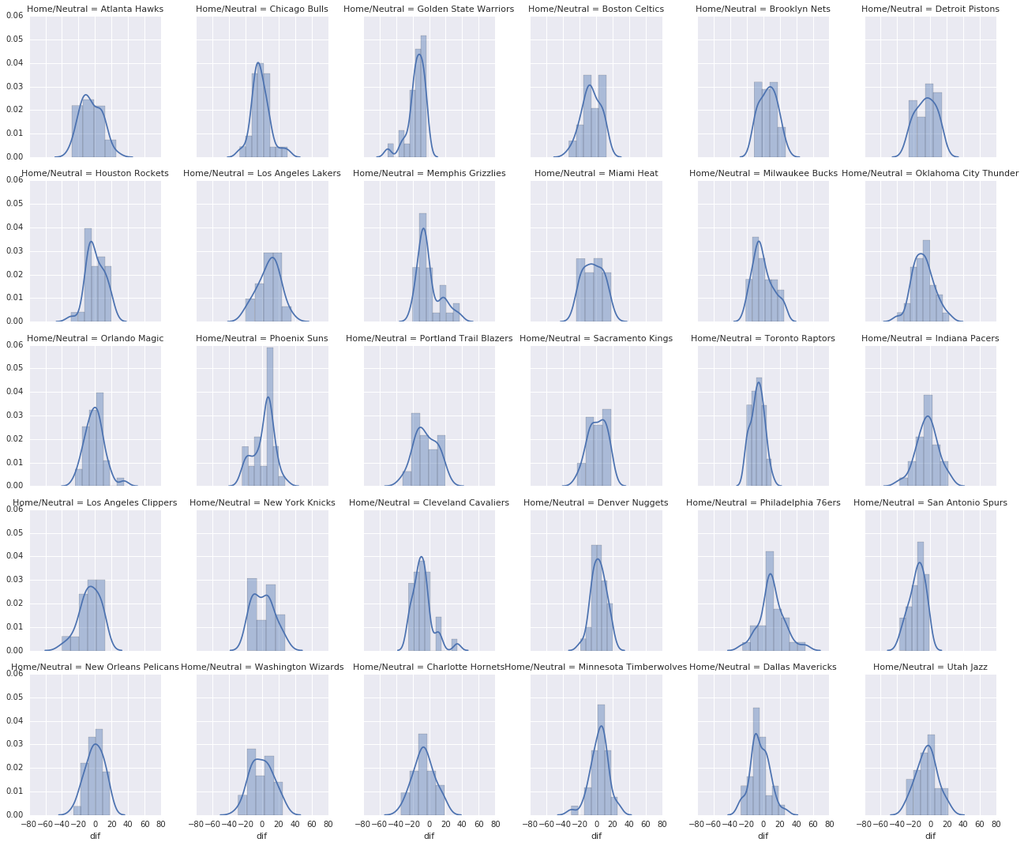

```python
grid = sns.FacetGrid(schedule, col = 'Home/Neutral',col_wrap=6)
grid.map(sns.distplot, 'dif')
```